# Práctica 3 - Proceso de dosificacion y control de peso medio en envasado (2ª parte): las decisiones de inversión.

Juan Riera

17/9/2021

## Introducción

En la práctica anterior hemos utilizado R para corregir un proceso de dosificación que estaba fuera de norma debido a que no habíamos tenido en cuenta la dispersión propia del proceso. También hemos visto cómo podemos utilizar R para establecer un objetivo de mejora, cuantificando su impacto económico de forma sencilla.

Vamos a ver ahora una alternativa a la mejora que habíamos planteado, que nos permite reducir aún más el peso dosificado apoyándonos en un sistema de pesaje automático, que necesita una inversión.

En la primera parte de este ejercicio ocultaremos el código que ya hemos visto en la práctica anterior, para mayor claridad.

Vamos a recuperar rápidamente los datos y cálculos que habíamos hecho en la práctica,

Recordemos que nuestro proceso envasa 3000 unidades diarias, y que envasamos 250 días al año. Veamos las primeras líneas de nuestra tabla:

Tabla de datos

| fecha | peso_real | simulacion1 | simulacion2 |
| --- | --- | --- | --- |
| 2020-05-16 09:00:00 | 254.6 | 263.9 | 258.7 |
| 2020-05-16 09:00:00 | 246.9 | 256.3 | 257.0 |
| 2020-05-16 09:00:00 | 236.3 | 245.7 | 251.7 |
| 2020-05-16 09:00:00 | 241.6 | 251.0 | 257.8 |
| 2020-05-16 09:00:00 | 247.4 | 256.8 | 256.2 |
| 2020-05-16 09:00:00 | 243.0 | 252.4 | 262.4 |

que podemos pasar a formato de *datos ordenados*. Veamos cómo:

```r
df |>
  pivot_longer(cols = c(peso_real,simulacion1,simulacion2), names_to = "caso", values_to = "peso") |>
  # desde aqui sólo formato encabezado para impresion
  head() |>
  kbl(caption = "Tabla de datos ordenados", digits = 1) |>
  kable_styling(bootstrap_options = c("hover", "condensed"),full_width = F)
```

Tabla de datos ordenados

| fecha | caso | peso |
| --- | --- | --- |
| 2020-05-16 09:00:00 | peso_real | 254.6 |
| 2020-05-16 09:00:00 | simulacion1 | 263.9 |
| 2020-05-16 09:00:00 | simulacion2 | 258.7 |
| 2020-05-16 09:00:00 | peso_real | 246.9 |
| 2020-05-16 09:00:00 | simulacion1 | 256.3 |
| 2020-05-16 09:00:00 | simulacion2 | 257.0 |

Hemos llamado $caso$ a cada una de nuestras alternativas, donde $caso$ puede tomar los valores

- $peso\_real$: para designar los pesos reales que hemos leído, provenientes de nuestro control en línea
- $simulacion1$: nuestra primera simulación, en la que aumentamos el peso linealmente, sin variar la desviación típica de nuestros pesos “reales”
- $simulacion2$: la segunda simulación, en la que establecimos una desviación típica objetivo de $6$, lo que nos permitió reducir en 4 gramos el peso dosificado que habíamos aumentado en $simulacion1$.

Recordemos nuestros valores reales de media y desviación típica, agrupando por $caso$:

Tabla resumen de medias y desviaciones típicas por caso

| caso | peso_medio | desv_t |
| --- | --- | --- |
| peso_real | 250.0 | 8.1 |
| simulacion1 | 259.4 | 8.1 |
| simulacion2 | 255.3 | 6.0 |

Habíamos comparado visualmente las distribuciones mediante la función de densidad y los diagramas de caja:

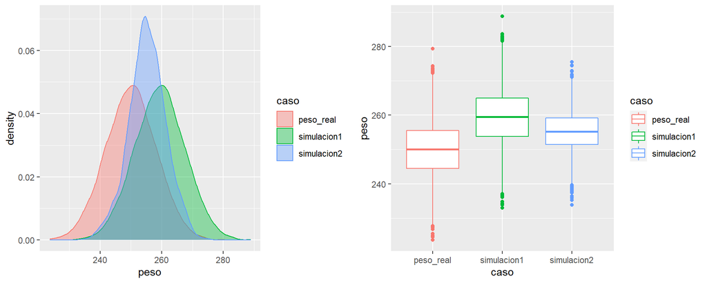

Calculamos también el porcentaje y número de casos de valores fuera de los límites de la norma de contenido efectivo, tanto con la funcion `sum()`, que nos daba directamente una frecuencia o número de casos, como con la función `pnorm()`, que nos calculaba la probabilidad de ocurrencia de un valor igual o menor que el dado, y que multiplicada por el número total (3000) nos daba el número de casos. La tabla siguiente resume el resultado de la aplicación de ambos métodos a los tres casos que estamos estudiando:

Tabla resumen

| caso | limite_control | metodo | resultado |
| --- | --- | --- | --- |
| peso | 241 | frecuencia | 399.0 |
| peso | 241 | probabilidad | 403.3 |
| peso | 232 | frecuencia | 40.0 |
| peso | 232 | probabilidad | 40.0 |
| simulacion1 | 241 | frecuencia | 34.0 |
| simulacion1 | 241 | probabilidad | 36.1 |
| simulacion1 | 232 | frecuencia | 0.0 |
| simulacion1 | 232 | probabilidad | 0.0 |
| simulacion2 | 241 | frecuencia | 43.0 |
| simulacion2 | 241 | probabilidad | 25.9 |
| simulacion2 | 232 | frecuencia | 0.0 |
| simulacion2 | 232 | probabilidad | 0.0 |

Una de las mayores fortalezas de $R$ es su gran potencia en la elaboración de gráficos estadísticos que pueden personalizarse totalmente hasta llegar a la figura que más os interesa para comunicar nuestro resultado. Como ejemplo, a continuación se muestra en forma gráfica la tabla resumen que acabamos de ver, con el fin de que podamos comparar ambos métodos de forma visual. Incluimos el código:

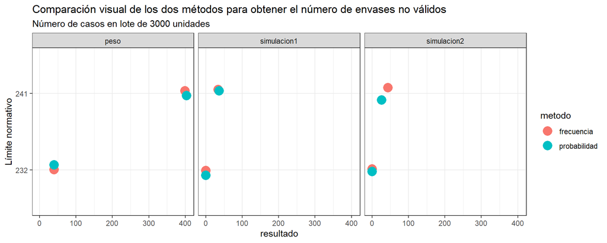

```r
ggplot(tabla_resumen, aes(resultado, factor(limite_control))) +
        geom_jitter(aes(color = metodo), height = 0.1, width = 0.2, size = 5) +
        facet_wrap(~caso) +
        labs( title = "Comparación visual de los dos métodos para obtener el número de envases no válidos",
              subtitle = "Número de casos en lote de 3000 unidades") +
        ylab("Límite normativo") +
        theme_bw()
```

El cálculo de lo que nos ha costado el producto envasado en cada caso es inmediato:

```r
coste_unitario <- 0.85

peso_real_kg <- sum(df$peso_real) /1000
peso_simul1_kg <- sum(df$simulacion1) /1000
peso_simul2_kg <- sum(df$simulacion2) /1000

coste_total_inicial <- peso_real_kg * coste_unitario
coste_total1 <- peso_simul1_kg * coste_unitario
coste_total2 <- peso_simul2_kg * coste_unitario

desviacion1 <- coste_total_inicial - coste_total1
desviacion2 <- coste_total1 -  coste_total2
```

- El coste del lote original, suponiendo nuestro coste unitario indicado en el código, de 0.85 euros/kg, ha sido de $coste\_total\_inicial=$ 637.52 euros/lote
- El coste total de nuestra primera simulación, después de la subida de peso, sería de $coste\_total1=$ 661.42 euros/lote. Este es el coste de referencia, si queremos nuestro lote en norma sin hacer cambios en nuestro proceso.
- Finalmente, el coste de nuestra segunda simulación, tras la reducción de la variabilidad que nos permite bajar el peso dosificado, sería de $coste\_total2=$ 650.97 euros/lote

Unos simples cálculos nos permiten saber el sobrecoste de la sobredosificación, y del ahorro por la reducción de la variabilidad:

Nuestra mejor opción hasta ahora es la $simulacion2$, que nos permite ahorrar 2611.33 euros anuales

## Revisando el plan de mejora

Hasta aquí hemos basado nuestra mejora en una reducción de la variabilidad, y hemos supuesto que que podíamos reducir nuestra desviación típica a $s=6$. Como ejercicio de simulación ha sido correcto; sin embargo, no tenemos ninguna evidencia de que en nuestra situación real seamos capaces de lograr esta reducción.

En el gráfico de control horario de nuestro proceso, habíamos visto que en un momento del envasado habíamos sido capaces de conseguir $s=7,54$, pero no menos.

Recordemos el gráfico de control y la tabla de nuestro peso original

```r
library(qcc)
peso_hora <- qcc.groups (df$peso_real, hour(df$fecha))
peso_grafico <- qcc(peso_hora, type = "S", nsigmas = 3)
```

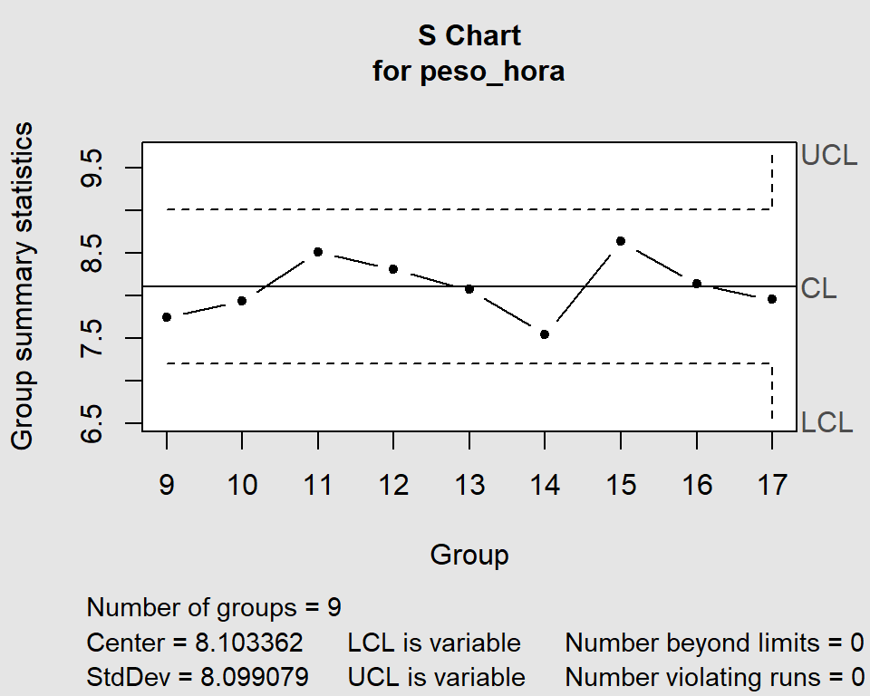

```r
df |>
 group_by(hora = hour(fecha)) |>
 summarise(media=mean(peso_real), desvt=sd(peso_real))
```

```
## # A tibble: 9 x 3
##    hora media desvt
##   <int> <dbl> <dbl>
## 1     9  250.  7.74
## 2    10  249.  7.94
## 3    11  249.  8.51
## 4    12  249.  8.30
## 5    13  251.  8.07
## 6    14  251.  7.54
## 7    15  250.  8.64
## 8    16  250.  8.13
## 9    17  251.  7.95
```

Como vemos, podemos ser capaces de conseguir una reducción de nuestra desviación típica de 8.15 g ($s$ para todo el periodo de envasado) a 7,5 g ($s$ en el periodo de 14:00 a 15:00), revisando y asegurando las condiciones de trabajo, personas y equipos que hemos tenido en ese periodo. Sin embargo, conseguir una $s=$ 6 es una hipótesis de trabajo que por el momento no tiene soporte en nuestra experiencia y conocimiento del proceso. Esto nos lleva a nuestro siguiente apartado.

### La fijación de los objetivos de mejora

En muchas ocasiones, la presión por conseguir on objetivo significativo, o el conocimiento insuficiente de nuestro proceso, nos lleva a establecer objetivos que no sabemos si podremos alcanzar. Algunas empresas ven esto como deseable, porque así aumentan el nivel de esfuerzo que esperan que realicen sus equipos, y se dicen que “aunque no se consiga el objetivo, si el nivel de exigencia es más alto, la mejora que se logrará será mejor”.

Esta reflexión, que es bastante frecuente, tiene, sin embargo, algunos inconvenientes importantes, entre ellos el error en el establecimiento del coste del producto, y por lo tanto, del precio de venta. Si suponemos que seremos capaces de reducir la desviación típica a 6, y por lo tanto, que vamos a reducir el peso dosificado en 4 gramos, como hemos visto en nuestra simulación, fijaremos un coste de producción acorde con este valor. Sin embargo,al no tener el conocimiento suficiente de las causas de la variación, no seremos capaces de alcanzarlo, y nuestro coste real será más alto, lo ue nos llevará a una situación de pérdidas económicas.

Por otra parte, la fijación de objetivos debe tener en cuenta siempre que esos objetivos sean alcanzables; fijar objetivos difíciles o imposibles de alcanzar puede originar frustración en los equipos de mejora.

El planteamiento correcto es proceder por etapas, asegurando la mejora, y, con ella, el conocimiento del proceso que nos ayudará a continuar el proceso de mejora. En esto consiste el proceso de mejora continua, a menudo conocido por las siglas en inglés DMAIC

Esto quiere decir que nustro primer paso debería ser el objetivo de la $s=$ 7,5.

Sin embargo, con esta $s$ no podemos asegurar la reducción de 4 gramos, porque nos aparecerían pesos por debajo de 232 gramos, como podemos ver con nuestra función de probabilidad, y suponiendo los valores de peso de nuestra $simulacion2$:

```r
p <- pnorm(232, mean(df$simulacion2), 7.5)
p
```

```
## [1] 0.0009536578
```

```r
p*3000
```

```
## [1] 2.860974
```

Es decir, con el peso de dosificación que hemos determinado para la $simulación2\text{ } \overline x=$ 255.28, tenemos 3 envases en 3000 que estarán por debajo del valor de rechazo de 232 g.

Si queremos asegurar que en ningún caso nos aparezcan estos envases deficientes, no tendríamos más remedio que subir nuestro peso medio, lo que implica no recuperar nuestros 4 gramos.

Sin embargo, en este caso, la tecnología puede venir en nuestra ayuda. Existen sistemas de pesado en continuo que permiten expulsar de la línea los envases por debajo de un peso que podemos programar; son los llamados [sistemas de pesaje con discriminadores de peso](https://www.google.com/search?q=discriminadores+de+peso&oq=discriminadores+de+peso&aqs=edge..69i57j0i22i30.3715j0j1&sourceid=chrome&ie=UTF-8). Con este sistema podemos eliminar de nuestro lote todos los envases con peso inferior a 232 g.

La decisión entonces es decidir el peso a dosificar de forma que el número de envases deficientes (peso <= 241 g) se mantenga en el límite especificado por la norma; en nuestro caso, si recordamos, $7$ en una muestra de $100$.

Veamos el porcentaje de envases deficientes de nuestra $simulacion2$ si conseguimos una desviación típica de $7,5$:

```r
p <- pnorm(241, mean(df$simulacion2), 7.5)
p*100
```

```
## [1] 2.843574
```

```r
p*3000
```

```
## [1] 85.30721
```

El porcentaje de envases deficientes con una $s=$ 7,5 y un peso medio de $\overline x=$ 255.28 es del 2.8%. Según esto, realmente podríamos bajar aún más el peso dosificado, hasta llehar al límite del 7% de envases deficientes, si no fuera por los envases con peso meor de 232 g. Pero nuestro sistema de expulsion va a eliminarlos, no tenemos problema.

Podemos ajustar nuestro peso mucho más cerca del valor nominal:

```r
p <- pnorm(241, 252.5, 7.5)
p*100
```

```
## [1] 6.259687
```

```r
p*3000
```

```
## [1] 187.7906
```

Si somos capaces de reducir la desviación típica a $s=$ `7,5`, podemos bajar el peso medio a $\overline x=$ `252,5` manteniendo el número de envases deficientes dentro de la norma.

```r
p <- pnorm(232, 252.5, 7.5)
p*100
```

```
## [1] 0.3134842
```

```r
p*3000
```

```
## [1] 9.404527
```

Obtenemos un porcentaje de 0.3% envases por debajo del peso de rechazo, es decir, 9 envases en cada lote; nuestro sistema de expulsión los eliminará de la línea, garantizando que cumplimos la norma.

Podemos recalcular ahora nuestros ahorros frente a la $simulacion1$ , la primera que habíamos realizado para estar dentro de norma subiendo el peso medio:

```r
df$simulacion3 <- rnorm(3000, 252.5, 7.5)
peso_simul3_kg <- sum(df$simulacion3) /1000

coste_total3 <- peso_simul3_kg * coste_unitario
desviacion3 <- coste_total1-coste_total3
```

- Peso envasado en la $simulacion3=$ 757.32 kilos
- Coste total del producto envasado en la $simulacion3=$ 643.7 euros
- Ahorro frente a la primera simulación: $coste\_total1-coste\_total3=$ 17.69 euros por lote, es decir, 4423 euros anuales.

Comparemos nuevamente de forma gráfica las tres simulaciones de peso:

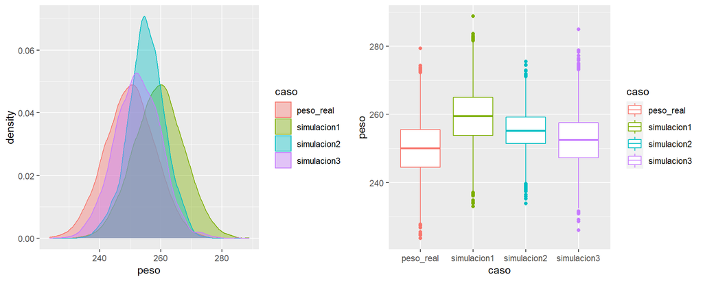

Hasta aquí parece que con el sistema de discriminador de peso conseguimos un resultado excelente,maximizando el ahorro de peso dosificado. Sin embargo, debemos revisar un último punto: ¿Justifican las economías previstas la ejecución de la inversión necesaria para el sistema de pesaje en continuo? ¿Debemos acometer esa inversión?

Ese será el tema de nuestro último punto.

## La decisión de inversión

La decisión de realziar una inversión de mejora debe ser siempre valorada con objetividad. En un mercado cambiante, como el actual, la recuperación del montante de la inversión debe valorarse con la mayor objetividad posible.

Hay que precisar que esta recuperación dela inversión no tiene nada que ver con el plazo de amortización, que es un concepto fiscal.

Un criterio sencillo de aplicar es el del **plazo de recuperación** de la inversión.

Veamos nuestro caso:

Imaginemos que el coste de la inversión es de 30.000 euros. Hemos visto que el ahorro de peso que proporciona la opción de instalar un discriminador nos proporciona un ahorro anual de 4423 euros anuales. esto quiere decir que el plazo de recuperación de la inversión es aproximadamente de 6.8 años, o lo que es lo mismo, en ese plazo habremos hecho unas economías que permitirán compensar el coste de la inversión.

Dado que las opciones de inversión para una empresa suelen ser varias, la empresa debe decidir cuál de ellas es la prioritaria. Entre los diversos criterios a disposición de la empresa para decidir la rentabilidad de una inversión, el **plazo de recuperación** ayuda a decidir que los recursos sean utilizados en la forma que antes se puedan recuperar. Algunas empresas incluso establecen un criterio de plazo mínimo: aquellas inversiones que no se recuperen en 3 años, por ejemplo, no serán validadas.

En nuestro caso, amortizar el sobrecoste gracias a la reducción del peso dosificado mediante un sistema de discriminación de peso no parece una buena decisión al coste de inversión previsto, o para el volumen que hemos planteado (250 días de fabricación de 3000 unidades al día); el plazo es demasiado largo y la empresa puede tener otras posibles inversiones que se recuperen en plazo más corto.

Pero si fuésemos capaces, por ejemplo, de encontrar un sistema de pesaje y discriminación de peso más económico o pudiésemos plantear una hipótesis realista de aumento de volumen de producción, podríamos reconsiderar la inversión. En este sentido, por ejemplo, se podría argumentar que la reducción del sobrepeso puede permitir abaratar el coste del producto, y en consecuencia aumentar las ventas, al ser capaces de ofrecer un precio más competitivo. Pero cuidado: ¡esta opción puede ser aún más complicada de cumplir que la reducción de la variabilidad a una $s=$`6`!

## Resumen

- Nuestro proceso de dosificación tiene una dispersión, descrita por su desviación típica $s=$ 8.15.
- Debido a esta dispersión, nos vemos obligados a dosificar un peso medio de $s=$ 259.4 para evitar estar fuera de la norma de contenido efectivo.
- Esta dosificación tiene un coste anual en producto dosificado de 165.353,8 euros
- Con el objetivo de mostrar de qué forma se puede conseguir un ahorro en el proceso de envasado, hemos hecho una simulación del proceso de dosificación utilizando una desviación típica menor que la original, que nos permitió, en la práctica anterior, reducir el peso de dosificación, con un ahorro de 2611. euros anuales
- Sin embargo, en una primera etapa, no sabemos cómo alcanzar esa desviación, con lo que no podemos estar seguros de los ahorros previstos. Esto compromete el resultado económico.
- Sabemos, sin embargo, que somos capaces de conseguir una desviación típica $s=$ `7,5` y ponemos este valor como objetivo alcanzable.
- Como con este valor, el porcentaje de envases deficientes es mucho menor de lo que permite la norma, podemos bajar nuestro peso medio dosificado aún más, hasta $\overline x=$ `252,5` gramos.
- Con este peso medio, obtenemos un porcentaje de productos deficientes aceptable por debajo del `7%`, pero nos aparecen envases por debajo del criterio de rechazo de 232 g que pueden hacer que nuestros lotes sean rechazados.
- Para evitar estos envases, decidimos realizar una inversión en un sistema de pesaje en continuo con discriminador de peso, que expulsará los envases deficientes. Esperamos un total de 9 envases rechazados por lote, que seguramente podremos reprocesar, y que, en todo caso, nos parece una cantidad asumible.
- Para decidir si realizamos la inversión, comparamos el **plazo de recuperación** con otras posibles inversiones a realizar, o con el plazo mínimo establecido por la empresa. En nuestro caso, el plazo de recuperación de la inversión es demasiado largo, y decidimos no comprometer la inversión. No podremos reducir el peso dosificado al límite previsto.
- Estudiamos sistemas alternativos de control de peso y expulsión de envases deficientes que tengan un coste más reducido; si nuestro **plazo de recuperación** sigue siendo demasiado alto, deberemos revisar de nuevo nuestro peso dosificado, para ajustarnos a la norma con una $s=$ `7,5`
- Ponemos en marcha un plan de mejora continua **DMAIC** para optimizar nuestro proceso de dosificación y seguir reduciendo nuestra variabilidad.